# WHO

```r
library(gridExtra)
library(ggpubr)
library(stringr)
library(dplyr)
```

# Why: Why is this a real problem that is worth solving?

We perform exploratory analysis on World Health Organization (WHO) datasets.

```r
mortality_rate <- read.csv(
  "mortality_rate.csv",
  stringsAsFactors = F
)

mortality_rate <- mortality_rate %>%
  mutate(
    Number.of.under.five.deaths..thousands. = as.numeric(Number.of.under.five.deaths..thousands.),
    Number.of.infant.deaths..thousands. = as.numeric(Number.of.infant.deaths..thousands.),
    Number.of.neonatal.deaths..thousands. = as.numeric(Number.of.neonatal.deaths..thousands.)
  )
mortality_rate[is.na(mortality_rate)] <- 0
```

```r
healthcare_expenditure <- read.csv(
  "healthcare_expenditure.csv",
  stringsAsFactors = F
)

healthcare_gdp <- bind_rows(
  healthcare_expenditure %>%
    transmute(
      Country = X,
      healthcare_expenditure_perc_gdp = Current.health.expenditure..CHE..as.percentage.of.gross.domestic.product..GDP.....,
      Year = 2015
    ),
  healthcare_expenditure %>%
    transmute(
      Country = X,
      healthcare_expenditure_perc_gdp = Current.health.expenditure..CHE..as.percentage.of.gross.domestic.product..GDP......1,
      Year = 2014
    ),
  healthcare_expenditure %>%
    transmute(
      Country = X,
      healthcare_expenditure_perc_gdp = Current.health.expenditure..CHE..as.percentage.of.gross.domestic.product..GDP......2,
      Year = 2013
    ),
  healthcare_expenditure %>%
    transmute(
      Country = X,
      healthcare_expenditure_perc_gdp = Current.health.expenditure..CHE..as.percentage.of.gross.domestic.product..GDP......3,
      Year = 2012
    ),
  healthcare_expenditure %>%
    transmute(
      Country = X,
      healthcare_expenditure_perc_gdp = Current.health.expenditure..CHE..as.percentage.of.gross.domestic.product..GDP......4,
      Year = 2011
    ),
  healthcare_expenditure %>%
    transmute(
      Country = X,
      healthcare_expenditure_perc_gdp = Current.health.expenditure..CHE..as.percentage.of.gross.domestic.product..GDP......5,
      Year = 2010
    ),
    healthcare_expenditure %>%
    transmute(
      Country = X,
      healthcare_expenditure_perc_gdp = Current.health.expenditure..CHE..as.percentage.of.gross.domestic.product..GDP......6,
      Year = 2009
    ),
    healthcare_expenditure %>%
    transmute(
      Country = X,
      healthcare_expenditure_perc_gdp = Current.health.expenditure..CHE..as.percentage.of.gross.domestic.product..GDP......7,
      Year = 2008
    ),
    healthcare_expenditure %>%
    transmute(
      Country = X,
      healthcare_expenditure_perc_gdp = Current.health.expenditure..CHE..as.percentage.of.gross.domestic.product..GDP......8,
      Year = 2007
    ),
    healthcare_expenditure %>%
    transmute(
      Country = X,
      healthcare_expenditure_perc_gdp = Current.health.expenditure..CHE..as.percentage.of.gross.domestic.product..GDP......9,
      Year = 2006
    ),
    healthcare_expenditure %>%
    transmute(
      Country = X,
      healthcare_expenditure_perc_gdp = Current.health.expenditure..CHE..as.percentage.of.gross.domestic.product..GDP......10,
      Year = 2005
    ),
    healthcare_expenditure %>%
    transmute(
      Country = X,
      healthcare_expenditure_perc_gdp = Current.health.expenditure..CHE..as.percentage.of.gross.domestic.product..GDP......11,
      Year = 2004
    ),
      healthcare_expenditure %>%
    transmute(
      Country = X,
      healthcare_expenditure_perc_gdp = Current.health.expenditure..CHE..as.percentage.of.gross.domestic.product..GDP......12,
      Year = 2003
    ),
      healthcare_expenditure %>%
    transmute(
      Country = X,
      healthcare_expenditure_perc_gdp = Current.health.expenditure..CHE..as.percentage.of.gross.domestic.product..GDP......13,
      Year = 2002
    ),
      healthcare_expenditure %>%
    transmute(
      Country = X,
      healthcare_expenditure_perc_gdp = Current.health.expenditure..CHE..as.percentage.of.gross.domestic.product..GDP......14,
      Year = 2001
    ),
      healthcare_expenditure %>%
    transmute(
      Country = X,
      healthcare_expenditure_perc_gdp = Current.health.expenditure..CHE..as.percentage.of.gross.domestic.product..GDP......15,
      Year = 2000
    )
)

healthcare_gdp <- healthcare_gdp %>%
  mutate(
    healthcare_expenditure_perc_gdp = as.numeric(healthcare_expenditure_perc_gdp)
  )
```

```r
demographic_rate_2013 <- read.csv(
  "2013_demographic_rates.csv",
  stringsAsFactors = F
) %>%
  rename(Country = X)
```

```r
population_2016 <- read.csv(
  "population_2016.csv",
  stringsAsFactors = F
) %>%
  transmute(
    Country = Country,
    Population..in.thousands..total = as.numeric(gsub(" ", "", Population..in.thousands..total))
  )
```

### Summarize each dataset

```r
summary(mortality_rate)
```

```
##    Country               Year      Number.of.under.five.deaths..thousands.
##  Length:5432        Min.   :1990   Min.   :   0.00
##  Class :character   1st Qu.:1997   1st Qu.:   0.00
##  Mode  :character   Median :2004   Median :   3.00
##                     Mean   :2004   Mean   :  45.61
##                     3rd Qu.:2010   3rd Qu.:  28.00
##                     Max.   :2017   Max.   :3399.00
##  Number.of.infant.deaths..thousands. Number.of.neonatal.deaths..thousands.
##  Min.   :   0.00                     Min.   :   0
##  1st Qu.:   0.00                     1st Qu.:   0
##  Median :   3.00                     Median :   2
##  Mean   :  32.39                     Mean   :  19
##  3rd Qu.:  22.00                     3rd Qu.:  11
##  Max.   :2387.00                     Max.   :1572
```

```r
summary(healthcare_gdp)
```

```
##    Country          healthcare_expenditure_perc_gdp      Year
##  Length:3120        Min.   :   0.80                 Min.   :2000
##  Class :character   1st Qu.:   4.40                 1st Qu.:2004
##  Mode  :character   Median :   5.80                 Median :2008
##                     Mean   :  16.85                 Mean   :2008
##                     3rd Qu.:   8.00                 3rd Qu.:2011
##                     Max.   :2015.00                 Max.   :2015
##                     NA's   :80
```

```r
summary(demographic_rate_2013)
```

```
##    Country          Crude.birth.rate..per.1000.population.
##  Length:195         Min.   :   6.80
##  Class :character   1st Qu.:  12.47
##  Mode  :character   Median :  19.90
##                     Mean   :  31.99
##                     3rd Qu.:  29.65
##                     Max.   :2013.00
##                     NA's   :1
##  Crude.death.rate..per.1000.population.
##  Min.   :   1.10
##  1st Qu.:   5.90
##  Median :   7.60
##  Mean   :  18.16
##  3rd Qu.:   9.60
##  Max.   :2013.00
##
```

### How does mortality rate compare for some countries of interest against United States?

Here since we do not have an accurate data on actual birth rate for each country, we will use 2013 birth rate as an estimate and assume it’s static across each year.

```r
total_births <- merge(
  demographic_rate_2013,
  population_2016,
  by=c("Country")
) %>%
  mutate(num_of_births = Population..in.thousands..total * Crude.birth.rate..per.1000.population.)


mortality_and_birth_rate <- merge(
  mortality_rate %>% mutate(total_infant_deaths = 1000.0 * Number.of.infant.deaths..thousands.),
  total_births,
  by = c("Country")
) %>%
  mutate(
    infant_death_rate = total_infant_deaths / num_of_births
  )
```

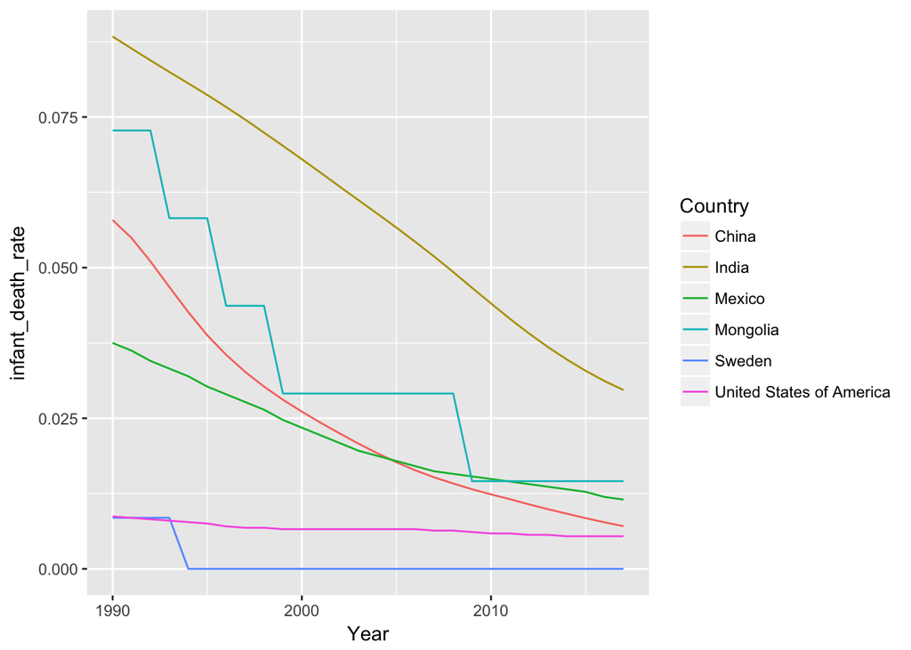

```r
mortality_and_birth_rate %>%
  filter(Country %in% c('Mongolia', 'United States of America', 'Mexico', 'Sweden', 'India', 'China')) %>%
  ggplot(aes(x = Year, y = infant_death_rate, color = Country)) +
    geom_line()
```

### How does current mortality rate looks among countries?

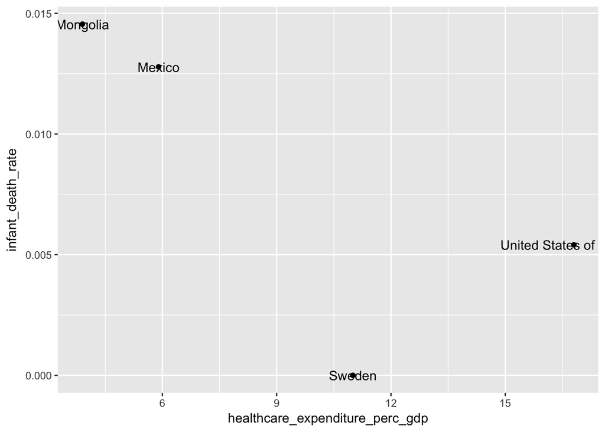

```r
merge(
  mortality_and_birth_rate,
  healthcare_gdp,
  by=c('Country', 'Year')
) %>%
  filter(
    Year == 2015,
    Country %in% c('Mongolia', 'United States of America', 'Mexico', 'Sweden')
  ) %>%
  ggplot(aes(x = healthcare_expenditure_perc_gdp, y = infant_death_rate, label = Country)) +
    geom_point() +
    geom_text()
```

How is the correlation between healthcare expenditure percenatage and mortality rate for all countries as of 2015?

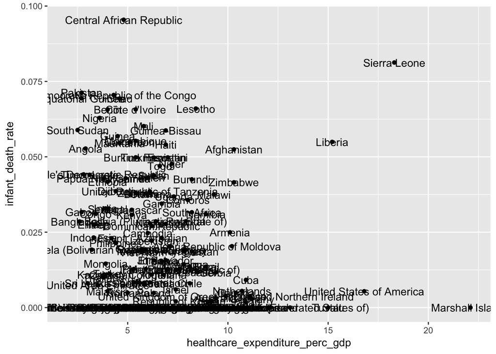

```r
merge(
  mortality_and_birth_rate,
  healthcare_gdp,
  by=c('Country', 'Year')
) %>%
  filter(
    Year == 2015
  ) %>%
  ggplot(aes(x = healthcare_expenditure_perc_gdp, y = infant_death_rate, label = Country)) +
    geom_point() +
    geom_text()
```

Here we do observe some outlier countries:

1. Sierra Leone spends significant portion of the country’s GDP on healthcare but survival rate is about 93%, which is relatively low among all countries (but note here that whole world made tremendous progress overall).

# How: How do we know if we have solved the problem?

# What: What does this look like in the product?

# Timeline

1. Finish 1-pager [2018-01-22]
2. Final deliverable [2018-02-29]

# References

https://www.who.int/gho/en/